# Red Wine Report

Maan Al Neami

2022-06-16

## Introdution

In this report we will be taking a look at a Red Wine dataset. The wine is called vinho verde wine from Portugal. We will be trying to find relationship between quality and other variables in the dataset. We will also be performing exploratory data analysis (EDA) on the dataset.

## Data

As mentioned above, the dataset is about red wine samples (vinho verde) from Portugal. The data was collected from May 2004 to February 2007. Only chemical properties of the wine are aviliable variables and quality as target. There is no data about grape types, wine brand or age, wine price etc.

| Variable | Description |
| --- | --- |
| fixed acidity | Tartaric acid and it plays in maintaining the chemical stability of the wine and its color and finally in influencing the taste of the finished wine. |
| volatile acidity | Acetic acid and it can lead to unpleasant vinegar taste. |
| citric acid | It can add flavor and freshness to wine. |
| residual sugar | The amount of sugar remaining after fermentation. |
| chlorides | Sodium chloride and it shows the amount of salt in wine. |
| free sulfur dioxide | the free form of Sulfur Dioxide(SO2) and it prevents the oxidation of wine. |
| total sulfur dioxide | Total Sulfur Dioxide(SO2). |
| density | Density of wine depends on the percent of alcohol and sugar. |
| pH | describes how acidic or basic a wine is, most wines are between 3-4. |
| sulphates | A wine additive that acts as an antioxidant. |
| alcohol | The percent of alcohol in wine. |
| quality | Quality of wine as a score between 0 and 10. |

```r
wine %>%
  clean_names() -> wine_df
```

- Lets also check for missing values

```r
sum(is.na(wine_df))
```

```
## [1] 0
```

Our dataset doesn’t contain any missing values so we don’t need to do furthur cleaning.

# EDA

Here we will be exploring and visulaizing our data

- First we will start by exploring our data by using `glimpse()` to see the dimensions of the dataset and the type of variables

```r
glimpse(wine_df)
```

```
## Rows: 1,599
## Columns: 12
## $ fixed_acidity        <dbl> 7.4, 7.8, 7.8, 11.2, 7.4, 7.4, 7.9, 7.3, 7.8, 7.5…
## $ volatile_acidity     <dbl> 0.700, 0.880, 0.760, 0.280, 0.700, 0.660, 0.600, …
## $ citric_acid          <dbl> 0.00, 0.00, 0.04, 0.56, 0.00, 0.00, 0.06, 0.00, 0…
## $ residual_sugar       <dbl> 1.9, 2.6, 2.3, 1.9, 1.9, 1.8, 1.6, 1.2, 2.0, 6.1,…
## $ chlorides            <dbl> 0.076, 0.098, 0.092, 0.075, 0.076, 0.075, 0.069, …
## $ free_sulfur_dioxide  <dbl> 11, 25, 15, 17, 11, 13, 15, 15, 9, 17, 15, 17, 16…
## $ total_sulfur_dioxide <dbl> 34, 67, 54, 60, 34, 40, 59, 21, 18, 102, 65, 102,…
## $ density              <dbl> 0.9978, 0.9968, 0.9970, 0.9980, 0.9978, 0.9978, 0…
## $ p_h                  <dbl> 3.51, 3.20, 3.26, 3.16, 3.51, 3.51, 3.30, 3.39, 3…
## $ sulphates            <dbl> 0.56, 0.68, 0.65, 0.58, 0.56, 0.56, 0.46, 0.47, 0…
## $ alcohol              <dbl> 9.4, 9.8, 9.8, 9.8, 9.4, 9.4, 9.4, 10.0, 9.5, 10.…
## $ quality              <int> 5, 5, 5, 6, 5, 5, 5, 7, 7, 5, 5, 5, 5, 5, 5, 5, 7…
```

- Lets also use `summary()` fo further explore the dataset

```r
summary(wine_df)
```

```
##  fixed_acidity   volatile_acidity  citric_acid    residual_sugar
##  Min.   : 4.60   Min.   :0.1200   Min.   :0.000   Min.   : 0.900
##  1st Qu.: 7.10   1st Qu.:0.3900   1st Qu.:0.090   1st Qu.: 1.900
##  Median : 7.90   Median :0.5200   Median :0.260   Median : 2.200
##  Mean   : 8.32   Mean   :0.5278   Mean   :0.271   Mean   : 2.539
##  3rd Qu.: 9.20   3rd Qu.:0.6400   3rd Qu.:0.420   3rd Qu.: 2.600
##  Max.   :15.90   Max.   :1.5800   Max.   :1.000   Max.   :15.500
##    chlorides       free_sulfur_dioxide total_sulfur_dioxide    density
##  Min.   :0.01200   Min.   : 1.00       Min.   :  6.00       Min.   :0.9901
##  1st Qu.:0.07000   1st Qu.: 7.00       1st Qu.: 22.00       1st Qu.:0.9956
##  Median :0.07900   Median :14.00       Median : 38.00       Median :0.9968
##  Mean   :0.08747   Mean   :15.87       Mean   : 46.47       Mean   :0.9967
##  3rd Qu.:0.09000   3rd Qu.:21.00       3rd Qu.: 62.00       3rd Qu.:0.9978
##  Max.   :0.61100   Max.   :72.00       Max.   :289.00       Max.   :1.0037
##       p_h          sulphates         alcohol         quality
##  Min.   :2.740   Min.   :0.3300   Min.   : 8.40   Min.   :3.000
##  1st Qu.:3.210   1st Qu.:0.5500   1st Qu.: 9.50   1st Qu.:5.000
##  Median :3.310   Median :0.6200   Median :10.20   Median :6.000
##  Mean   :3.311   Mean   :0.6581   Mean   :10.42   Mean   :5.636
##  3rd Qu.:3.400   3rd Qu.:0.7300   3rd Qu.:11.10   3rd Qu.:6.000
##  Max.   :4.010   Max.   :2.0000   Max.   :14.90   Max.   :8.000
```

We see that the qulity of the wine in this dataset is between 3 to 8

*Plotting*

- Let take a look at the distribution of our data by quality

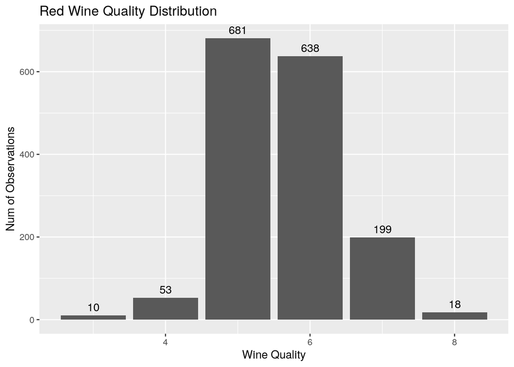

```r
ggplot(wine_df, aes(x=quality, fill = quality)) +
  geom_bar(stat="count") +
  geom_text(position = "stack", stat='count',aes(label=..count..), vjust = -0.5)+
  labs(y="Num of Observations", x="Wine Quality") +
  labs(title= "Red Wine Quality Distribution")
```

We can see from this graph that most of our data is in mid range quality with few very high or low quality wine.